# Assingnment3

01. create an numpy array of 10 random int form 1 & 100 then perform basic operation. 02. create an 3x3 matrix then calculate sum of each column and each row. 03. create a pandas data frame from dictionary then performs basic operations. 04. read a csv file into a data frame then filter and group the data. 05. create a line, scatter plots using matplotlib 06. create a bar plot using matplotlib 07. create a 2 numpy array and perform element vise +,-,*&/. 08. load a csv file in a data frame clean the data by handling missing value and display the clean dataframe. 09. merge 2 dataframe and perfrom basic analysis. 10.create a pie chart to show the distribution of dataset

1. create an numpy array of 10 random int form 1 & 100 then perform basic operation.

```python
import numpy as np
arr=np.random.randint(1,101, size=10)
print("Random array:\n",arr)
print("Array Sum:",np.sum(arr))
print("Array Mean:",np.mean(arr))
print("Array Max:",np.max(arr))
print("Array Min:",np.min(arr))
```

```
Random array:
 [97 84 37 25 73 20 49  2 95 59]
Array Sum: 541
Array Mean: 54.1
Array Max: 97
Array Min: 2
```

2. create an 3x3 matrix then calculate sum of each column and each row.

```python
import numpy as np
arr=np.array([[[1,2,3],
               [4,5,6],
               [7,8,9]]])
col_sum=arr.sum(axis=1)
row_sum=arr.sum(axis=2)
print("Sum of each Column:",col_sum)
print("Sum of each Row:",row_sum)
```

```
Sum of each Column: [[12 15 18]]
Sum of each Row: [[ 6 15 24]]
```

3.create a pandas data frame from dictionary then performs basic operations.

```python
import pandas as pd
data={'ID':['U101','U102','U103','U104'],
      'Name':['A','B','C','D'],
      'Course':['BSc','BCom','BA','BSc'],
     }
df=pd.DataFrame(data)
print("Created Data Frame is:")
print(df)
print("\nAccessing the Columns:")
print("\nSingle Column:\n",df['Name'])
print("\nMulti Columns:\n",df[['Name','Course']])
print("\nAccessing the Rows:")
print("\nSingle Row:\n",df.loc[1])
print("\nMulti Rows:\n",df.loc[[1,3]])
print("\nFiltering the data:\n")
print(df[df['Course']=='BSc'])
print("\nAdding Marks column:\n")
df['Marks']=[85,90,70,95]
print(df)
print("\nDeleting the Marks column:\n")
del df['Marks']
print(df)
```

```
Created Data Frame is:
     ID Name Course
0  U101    A    BSc
1  U102    B   BCom
2  U103    C     BA
3  U104    D    BSc

Accessing the Columns:

Single Column:
 0    A
1    B
2    C
3    D
Name: Name, dtype: object

Multi Columns:
   Name Course
0    A    BSc
1    B   BCom
2    C     BA
3    D    BSc

Accessing the Rows:

Single Row:
 ID        U102
Name         B
Course    BCom
Name: 1, dtype: object

Multi Rows:
      ID Name Course
1  U102    B   BCom
3  U104    D    BSc

Filtering the data:

     ID Name Course
0  U101    A    BSc
3  U104    D    BSc

Adding Marks column:

     ID Name Course  Marks
0  U101    A    BSc     85
1  U102    B   BCom     90
2  U103    C     BA     70
3  U104    D    BSc     95

Deleting the Marks column:

     ID Name Course
0  U101    A    BSc
1  U102    B   BCom
2  U103    C     BA
3  U104    D    BSc
```

4. read a csv file into a data frame then filter and group the data

```python
import pandas as pd
df=pd.read_csv(r'C:\Users\sksam\Downloads\Student.csv')
print("Give DataFrame is:\n",df)
print("\nFiltering Data if Marks > 85:\n",df[df['Marks']>85])
print("\nFiltering Data if Age=21:\n",df[df['Age']==21])
print("\nGrouping data of only BSc:\n",df[df['Course']=='BSc'])
print("\nGrouping data of only BCom:\n",df[df['Course']=='BCom'])
print("\nGrouping data of only BA:\n",df[df['Course']=='BA'])
```

```
Give DataFrame is:
   Name    ID Course  Marks  Age
0    A  U101    BSc     90   21
1    B  U102    BSc     80   20
2    C  U103   BCom     87   22
3    D  U104     BA     76   21
4    E  U105   BCom     79   20
5    F  U106     BA     97   22
6    G  U107   BCom     98   20
7    H  U108    BSc     89   21
8    I  U109    BSc     84   22

Filtering Data if Marks > 85:
   Name    ID Course  Marks  Age
0    A  U101    BSc     90   21
2    C  U103   BCom     87   22
5    F  U106     BA     97   22
6    G  U107   BCom     98   20
7    H  U108    BSc     89   21

Filtering Data if Age=21:
   Name    ID Course  Marks  Age
0    A  U101    BSc     90   21
3    D  U104     BA     76   21
7    H  U108    BSc     89   21

Grouping data of only BSc:
   Name    ID Course  Marks  Age
0    A  U101    BSc     90   21
1    B  U102    BSc     80   20
7    H  U108    BSc     89   21
8    I  U109    BSc     84   22

Grouping data of only BCom:
   Name    ID Course  Marks  Age
2    C  U103   BCom     87   22
4    E  U105   BCom     79   20
6    G  U107   BCom     98   20

Grouping data of only BA:
   Name    ID Course  Marks  Age
3    D  U104     BA     76   21
5    F  U106     BA     97   22
```

5. create a line, scatter plots using matplotlib

```
Line Chart
```

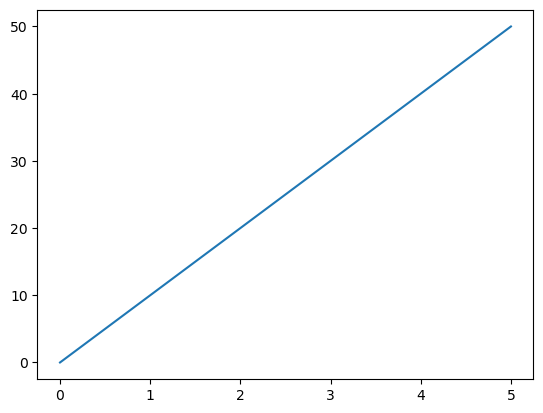

```
Scatter Chart
```

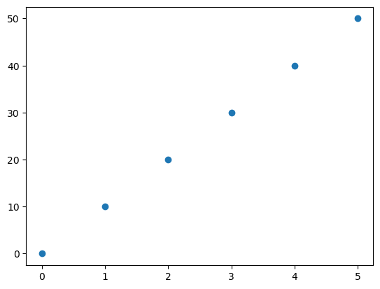

```python
import matplotlib.pyplot as plt
import numpy as np
x=np.array([0,1,2,3,4,5])
y=np.array([0,10,20,30,40,50])
print("Line Chart\n")
plt.plot(x,y)
plt.show()
print("Scatter Chart\n")
plt.scatter(x,y)
plt.show()
```

6. create a bar plot using matplotlib

```
Bar chart
```

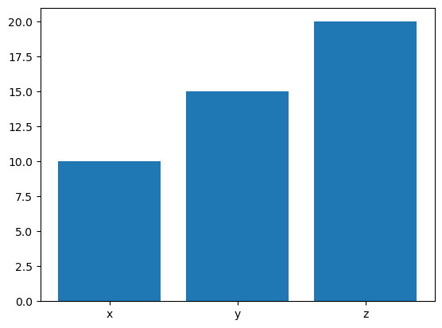

```python
print("Bar chart\n")
a=np.array(['x','y','z'])
b=np.array([10,15,20])
plt.bar(a,b)
plt.show()
```

7. create a 2 numpy array and perform element vise +,-,*,/.

```python
ar1=np.array([[[1,2,3],[4,5,6],[7,8,9]]])
ar2=np.array([[[1,2,3],[4,5,6],[7,8,9]]])
print("Addtion of 2 array:\n",(ar1+ar2))
print("Subtraction of 2 array:\n",(ar1-ar2))
print("Multiplication of 2 array:\n",(ar1*ar2))
print("Division of 2 array:\n",(ar1/ar2))
```

```
Addtion of 2 array:
 [[[ 2  4  6]
  [ 8 10 12]
  [14 16 18]]]
Subtraction of 2 array:
 [[[0 0 0]
  [0 0 0]
  [0 0 0]]]
Multiplication of 2 array:
 [[[ 1  4  9]
  [16 25 36]
  [49 64 81]]]
Division of 2 array:
 [[[1. 1. 1.]
  [1. 1. 1.]
  [1. 1. 1.]]]
```

8. load a csv file in a data frame clean the data by handling missing value and display the clean dataframe.

```python
import pandas as pd
df=pd.read_csv(r'C:\Users\sksam\Downloads\Student1.csv')
print("Given DataFrame:\n",df)
df2=df.fillna('missing')
print("Cleaned DataFrame:\n",df2)
df3=df.dropna()
print("Cleaned DataFrame:\n",df3)
```

```
Given DataFrame:
   Name    ID Course  Marks   Age
0    A  U101    BSc   90.0  21.0
1    B  U102    BSc   80.0  20.0
2    C  U103   BCom   87.0   NaN
3    D  U104     BA    NaN  21.0
4    E  U105   BCom   79.0  20.0
5    F  U106     BA   97.0   NaN
6    G  U107   BCom    NaN  20.0
7    H  U108    BSc   89.0  21.0
8    I  U109    BSc   84.0   NaN
Cleaned DataFrame:
   Name    ID Course    Marks      Age
0    A  U101    BSc     90.0     21.0
1    B  U102    BSc     80.0     20.0
2    C  U103   BCom     87.0  missing
3    D  U104     BA  missing     21.0
4    E  U105   BCom     79.0     20.0
5    F  U106     BA     97.0  missing
6    G  U107   BCom  missing     20.0
7    H  U108    BSc     89.0     21.0
8    I  U109    BSc     84.0  missing
Cleaned DataFrame:
   Name    ID Course  Marks   Age
0    A  U101    BSc   90.0  21.0
1    B  U102    BSc   80.0  20.0
4    E  U105   BCom   79.0  20.0
7    H  U108    BSc   89.0  21.0
```

9. merge 2 dataframe and perfrom basic analysis.

```python
print("Question: 09")
import pandas as pd
data={'Name':['A','B','C','D'],
      'ID':[101,102,103,104],
      'Age':[25,24,20,21],
      'Course':['BSc','Bcom','BSc','Bcom']
     }
data2={'Name':['E','F','G','H'],
       'ID':[105,106,107,108],
      'Age':[20,22,24,21],
      'Course':['BSc','Bsc','BSc','Bcom']
     }
df1=pd.DataFrame(data)
df2=pd.DataFrame(data2)
print(df1)
print(df2)
frame=[df1,df2]
df3=pd.concat(frame)
display(df3)
df3.head(3)
df3.tail(3)
df3.info()
```

```
Question: 09
  Name   ID  Age Course
0    A  101   25    BSc
1    B  102   24   Bcom
2    C  103   20    BSc
3    D  104   21   Bcom
  Name   ID  Age Course
0    E  105   20    BSc
1    F  106   22    Bsc
2    G  107   24    BSc
3    H  108   21   Bcom
```

|  | Name | ID | Age | Course |
| --- | --- | --- | --- | --- |
| 0 | A | 101 | 25 | BSc |
| 1 | B | 102 | 24 | Bcom |
| 2 | C | 103 | 20 | BSc |
| 3 | D | 104 | 21 | Bcom |
| 0 | E | 105 | 20 | BSc |
| 1 | F | 106 | 22 | Bsc |
| 2 | G | 107 | 24 | BSc |
| 3 | H | 108 | 21 | Bcom |

```
<class 'pandas.core.frame.DataFrame'>
Index: 8 entries, 0 to 3
Data columns (total 4 columns):
 #   Column  Non-Null Count  Dtype
---  ------  --------------  -----
 0   Name    8 non-null      object
 1   ID      8 non-null      int64
 2   Age     8 non-null      int64
 3   Course  8 non-null      object
dtypes: int64(2), object(2)
memory usage: 320.0+ bytes
```

10.create a pie chart to show the distribution of dataset.

```
Pie Chart
```

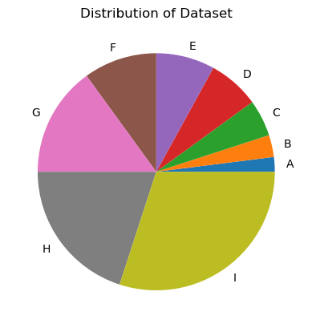

```python
import numpy as np
import matplotlib.pyplot as plt
print("Pie Chart")
x=np.array([2,3,5,7,8,10,15,20,30])
y=np.array(['A','B','C','D','E','F','G','H','I'])
plt.pie(x, labels=y)
plt.title('Distribution of Dataset')
plt.show()
```